# ggradar Tidy Tuesday Demo

Cameryn Brock

5/25/2021

### Install packages

#### `ggradar`

`ggradar` is a package for making radar charts with ggplot syntax made by Ricardo Bion. See information here: https://github.com/ricardo-bion/ggradar. If you need to download, can download with `devtools::install_github("ricardo-bion/ggradar", dependencies = TRUE)`

#### `calecopal`

`calecopal` is a package with color palettes inspired by California. See information and color palettes here: https://github.com/an-bui/calecopal. You can view all palette names with `names(cal_palettes)`. If you need to download, can download with `devtools::install_github("an-bui/calecopal")`

#### `tidytuesdayR`

`tidytuesdayR` is a package for easy access to Tidy Tuesday datasets. See information here: https://github.com/rfordatascience/tidytuesday

```r
library(ggradar) # radar plots
library(calecopal) # california color palettes
library(tidytuesdayR) # tidy tuesday data
library(janitor) # data cleaning
library(tidyverse)
```

### Read in data

We will be using data for global crop yields from Our World in Data. https://github.com/rfordatascience/tidytuesday/blob/master/data/2020/2020-09-01/readme.md

```r
crops <- tidytuesdayR::tt_load('2020-09-01')
crops_clean <- crops$key_crop_yields %>%
  clean_names() %>%
  rename_with( ~ str_remove(., pattern = "_tonnes_per_hectare"))
```

### Clean up and focus data to our interest

```r
# warning that 'entity' contains countries, continents, and regions
# unique(crops$entity)
# filter to just continent-level
# select only crops of interest

crops_focal <- crops_clean %>%
  filter(
    entity %in% c("Northern America",
                  "Central America",
                  "South America",
                  "Europe",
                  "Asia",
                  "Europe",
                  "Africa")) %>%
  rename("region" = entity) %>%
  mutate(region = factor(
    region,
    levels = c(
      "Northern America",
      "Central America",
      "South America",
      "Europe",
      "Asia",
      "Africa"))) %>%
select(region,
         year,
         wheat,
         rice,
         maize,
         soybeans,
         potatoes,
         beans,
         bananas)
```

### Standarize for consistent axes

```r
# store max values for later

max_wheat <- max(crops_focal$wheat, na.rm = TRUE)
max_rice <- max(crops_focal$rice, na.rm = TRUE)
max_maize <- max(crops_focal$maize, na.rm = TRUE)
max_soy <- max(crops_focal$soybeans, na.rm = TRUE)
max_pot <- max(crops_focal$potatoes, na.rm = TRUE)
max_beans <- max(crops_focal$beans, na.rm = TRUE)
max_ban <- max(crops_focal$bananas, na.rm = TRUE)

# standardize by max value
crops_stand <- crops_focal %>%
  mutate(
    wheat = wheat / max_wheat,
    rice = rice / max_rice,
    maize = maize / max_maize,
    soybeans = soybeans / max_soy,
    potatoes = potatoes / max_pot,
    beans = beans / max_beans,
    bananas = bananas / max_ban)
```

### Let’s look at 2018 first…

```r
# filter to only 2018 values

crops_2018 <- crops_stand %>%
  filter(year == 2018) %>%
  select(!year)
```

You may be thinking you can just make a line graph in ggplot and use coord_polar… you cannot!

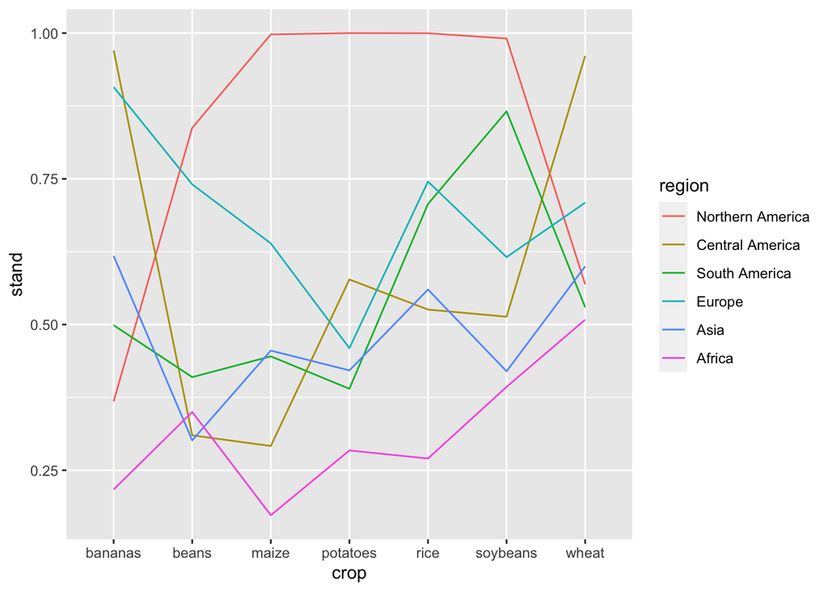

```r
crops_ggplot <- crops_2018 %>%
  pivot_longer(2:8,
               names_to = "crop",
               values_to = "stand")

ggplot(crops_ggplot, aes(x = crop, y = stand, group = region, color = region)) +
  geom_line()
```

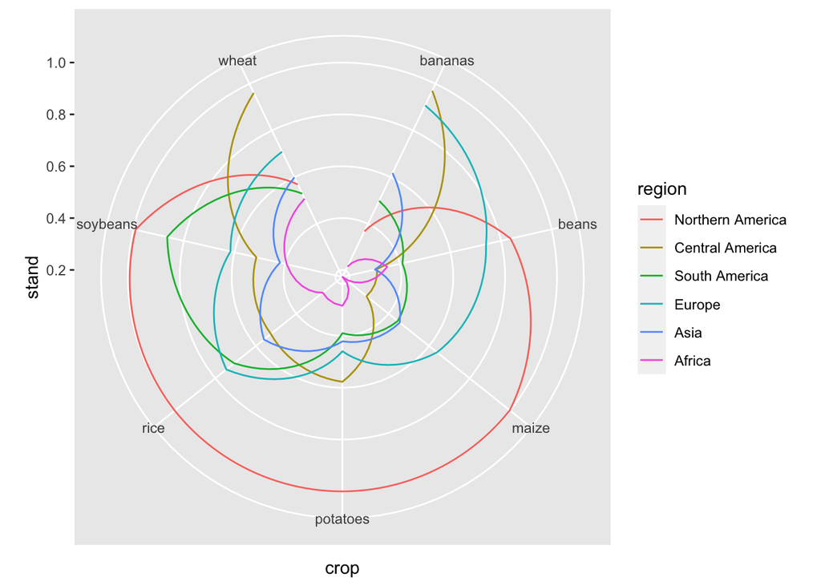

```r
ggplot(crops_ggplot, aes(x = crop, y = stand, group = region, color = region)) +
  geom_line() +
  coord_polar()
```

Instead, we’ll be using `ggradar`

Here’s what the generic output looks like:

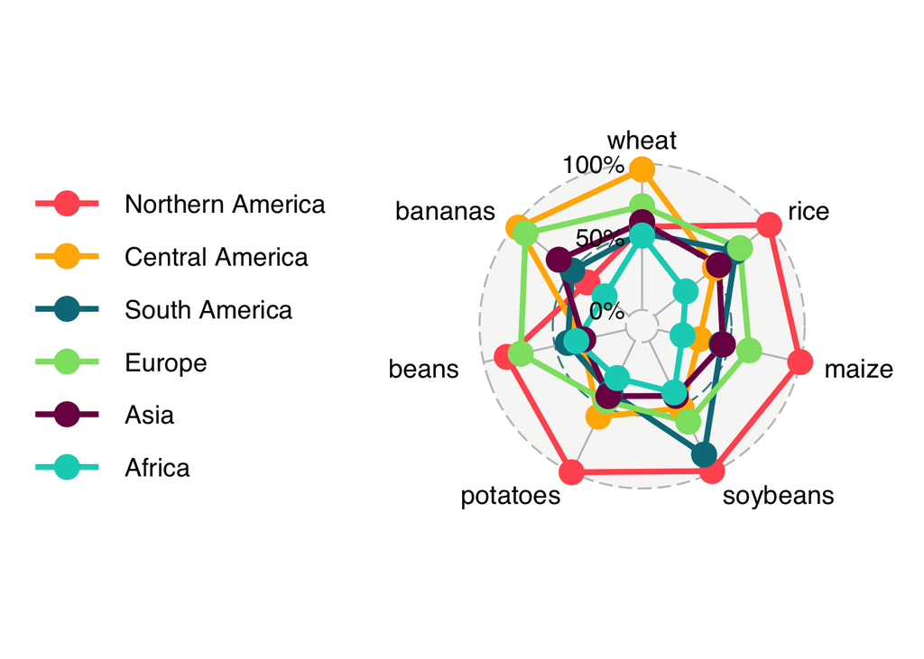

```r
# generic output
ggradar(crops_2018)
```

But we can also make it prettier

```r
# colors that are (generally..) similar among regions
my_cat_colors <- cal_palette("figmtn")

# sequential colors for by year
my_seq_colors <- cal_palette("sierra1", n = 11, type = "continuous")

# pretty labels
my_labels = c("Wheat", "Rice", "Maize",
              "Soybeans", "Potatoes", "Beans",
              "Bananas")
```

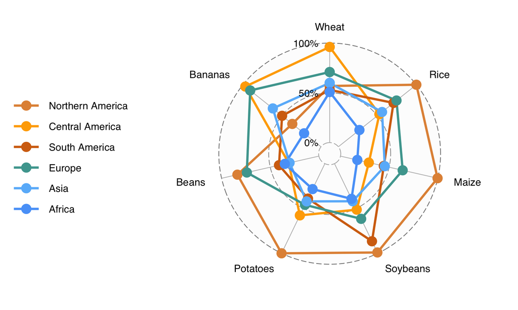

```r
ggradar(
  crops_2018,
  axis.labels = my_labels,
  background.circle.transparency = 0.05,
  gridline.min.colour = "gray70",
  gridline.mid.colour = "gray60",
  gridline.max.colour = "gray50") +
  scale_color_manual(values = my_cat_colors)
```

#### Now let’s look at each region over time

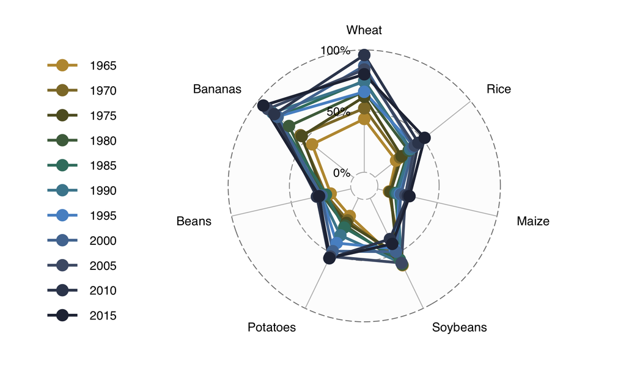

```r
crops_yearly <- crops_stand %>%
  filter(year %in% c(seq(from = 1960, to = 2020, by = 5)))

# Central America

crops_ca <- crops_yearly %>%
  filter(region == "Central America") %>%
  select(!region)

ggradar(
  crops_ca,
  axis.labels = my_labels,
  background.circle.transparency = 0.05,
  gridline.min.colour = "gray70",
  gridline.mid.colour = "gray60",
  gridline.max.colour = "gray50") +
  scale_color_manual(values = my_seq_colors)
```

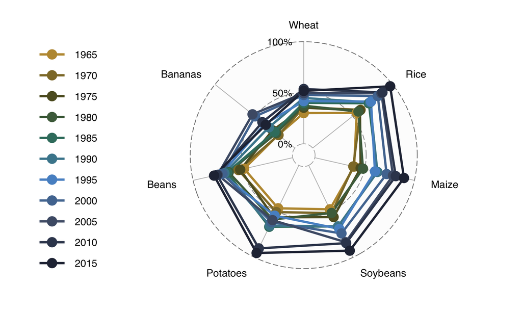

```r
## North America

crops_na <- crops_yearly %>%
  filter(region == "Northern America") %>%
  select(!region)

ggradar(
  crops_na,
  axis.labels = my_labels,
  background.circle.transparency = 0.05,
  gridline.min.colour = "gray70",
  gridline.mid.colour = "gray60",
  gridline.max.colour = "gray50") +
  scale_color_manual(values = my_seq_colors)
```

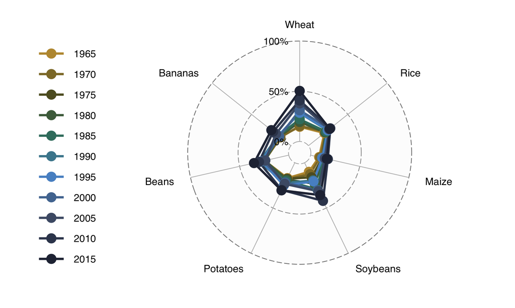

```r
# Africa

crops_af <- crops_yearly %>%
  filter(region == "Africa") %>%
  select(!region)

ggradar(crops_af,
        axis.labels = my_labels,
        background.circle.transparency = 0.05,
        gridline.min.colour = "gray70",
        gridline.mid.colour = "gray60",
        gridline.max.colour = "gray50") +
  scale_color_manual(values = my_seq_colors)
```

#### Caveats to using radar charts

https://www.data-to-viz.com/caveat/spider.html

- Circular layout is hard to read
- Difficult to find ranking with no clear order
- Category order has large impact
- Scales can be confusing
- Difficult to evaluate differences
- Overplotting can make chart hard to read

Good application example:

Clark, M. A., Springmann, M., Hill, J., & Tilman, D. (2019). Multiple health and environmental impacts of foods. Proceedings of the National Academy of Sciences, 116(46), 23357–23362. https://doi.org/10.1073/pnas.1906908116